# 一、贝叶斯分类器

## 1.极大似然估计

先验极大似然估计的概率：

$P(Y = c_k) = \frac{\Sigma_{i=1}^N I(y_i = c_k)}{N}$

在本题中有，

$P(Y = 1) = \frac{5}{15} = \frac{1}{3}$  
$P(Y = -1) = \frac{10}{15} = \frac{2}{3}$

条件概率极大似然估计：

$P(X^{(j)} = a_{jl}|Y = c_k) = \frac{\Sigma_i I(x_i^{(j)} = a_{jl}, y_i = c_k)}{\Sigma_i I(y_i = c_k)}$

在本题中有，

$P(X^{(1)} = 1|Y = 1) = \frac{1}{5}$  
$P(X^{(1)} = 2|Y = 1) = \frac{3}{5}$  
$P(X^{(1)} = 3|Y = 1) = \frac{1}{5}$  
$P(X^{(1)} = 1|Y = -1) = \frac{2}{10}=\frac{1}{5}$  
$P(X^{(1)} = 2|Y = -1) = \frac{2}{10}=\frac{1}{5}$  
$P(X^{(1)} = 3|Y = -1) = \frac{6}{10}=\frac{3}{5}$

$P(X^{(2)} = S|Y = 1) = \frac{1}{5}$  
$P(X^{(2)} = M|Y = 1) = \frac{2}{5}$  
$P(X^{(2)} = L|Y = 1) = \frac{2}{5}$  
$P(X^{(2)} = S|Y = -1) = \frac{3}{10}$  
$P(X^{(2)} = M|Y = -1) = \frac{4}{10}=\frac{2}{5}$  
$P(X^{(2)} = L|Y = -1) = \frac{3}{10}$

对于题目中给定$x = (2,M)^T$

$P(Y = 1|x)的分子 = P(Y = 1)P(X^{(1)} = 2|Y = 1)P(X^{(2)} = M|Y = 1) = \frac{1}{3} \times \frac{3}{5} \times \frac{2}{5} = \frac{2}{25}$  
$P(Y = -1|x)的分子 = P(Y = -1)P(X^{(1)} = 2|Y = -1)P(X^{(2)} = M|Y = -1) = \frac{2}{3} \times \frac{1}{5} \times \frac{2}{5} = \frac{4}{75}$

$P(Y = 1|x) > P(Y = -1|x)$

故样本$x = (2,M)^T$的分类是$Y = 1$

## 2.贝叶斯估计

记$K$为Y的可能取值个数，$S_j$为$x^{(j)}$的可能取值个数，则有

先验概率：

$P_\lambda(Y = c_k) = \frac{\Sigma_{i=1}^N I(y_i = c_k) + \lambda}{N + K\lambda}$

条件概率估计：

$P_\lambda(X^{(j)} = a_{jl}|Y = c_k) = \frac{\Sigma_i I(x_i^{(j)} = a_{jl}, y_i = c_k) + \lambda}{\Sigma_i I(y_i = c_k)+ S_j \lambda}$

本题中取$\lambda = 1$，则有：

$K = 2, S_1 = 3, S_2 = 3$

$P_\lambda(Y = 1) = \frac{5 + 1}{15 + 2} = \frac{6}{17}$  
$P_\lambda(Y = -1) = \frac{10 + 1}{15 + 2} = \frac{11}{17}$

$P_\lambda(X^{(1)} = 1|Y = 1) = \frac{1+1}{5+3} = \frac{1}{4}$  
$P_\lambda(X^{(1)} = 2|Y = 1) = \frac{3+1}{5+3}= \frac{1}{2}$  
$P_\lambda(X^{(1)} = 3|Y = 1) = \frac{1+1}{5+3}= \frac{1}{4}$  
$P_\lambda(X^{(1)} = 1|Y = -1) = \frac{2+1}{10+3}=\frac{3}{13}$  
$P_\lambda(X^{(1)} = 2|Y = -1) = \frac{2+1}{10+3}=\frac{3}{13}$  
$P_\lambda(X^{(1)} = 3|Y = -1) = \frac{6+1}{10+3}=\frac{7}{13}$

$P_\lambda(X^{(2)} = S|Y = 1) = \frac{1+1}{5+3}= \frac{1}{4}$  
$P_\lambda(X^{(2)} = M|Y = 1) = \frac{2+1}{5+3}= \frac{3}{8}$  
$P_\lambda(X^{(2)} = L|Y = 1) = \frac{2+1}{5+3}= \frac{3}{8}$  
$P_\lambda(X^{(2)} = S|Y = -1) = \frac{3+1}{10+3}= \frac{4}{13}$  
$P_\lambda(X^{(2)} = M|Y = -1) = \frac{4+1}{10+3}=\frac{5}{13}$  
$P_\lambda(X^{(2)} = L|Y = -1) = \frac{3+1}{10+3}= \frac{4}{13}$

对于题目中给定$x = (2,M)^T$

$P_\lambda(Y = 1|x)的分子 = P_\lambda(Y = 1)P_\lambda(X^{(1)} = 2|Y = 1)P_\lambda(X^{(2)} = M|Y = 1) = \frac{6}{17} \times \frac{1}{2} \times \frac{3}{8} = \frac{9}{136} = 0.066$  
$P_\lambda(Y = -1|x)的分子 = P_\lambda(Y = -1)P_\lambda(X^{(1)} = 2|Y = -1)P_\lambda(X^{(2)} = M|Y = -1) = \frac{11}{17} \times \frac{3}{13} \times \frac{5}{13} = \frac{165}{2873} = 0.057$

$P_\lambda(Y = 1|x) > P_\lambda(Y = -1|x)$

故样本$x = (2,M)^T$的分类是$Y = 1$

# 二、基于商品名称的自动化分类数据分析

## 1.数据读取

```python
import pandas as pd
catalog = pd.read_csv('data/catalogs.csv')
catalog.head()
```

|  | name | first | second | third |
| --- | --- | --- | --- | --- |
| 0 | 双汇 猪舌 700g/袋 | 生鲜 | 猪牛羊肉 | 猪肉 |
| 1 | （满38减10）黑猪腊肉 湘西腊肉 即食小吃食猪肉干肉脯湖南张家界土家 香辣味 | 生鲜 | 猪牛羊肉 | 猪肉 |
| 2 | 精气神 猪肋排段（排骨） 400g/袋 山黑猪 黑猪肉 林间散养 | 生鲜 | 猪牛羊肉 | 猪肉 |
| 3 | 双汇 猪五花肉片 300g/袋 整肉原切 火锅食材 | 生鲜 | 猪牛羊肉 | 猪肉 |
| 4 | 农家散养新鲜现杀黑土猪肉 纯瘦肉 500g | 生鲜 | 猪牛羊肉 | 猪肉 |

## 2.饼状图

品类为生鲜的饼状图展示：

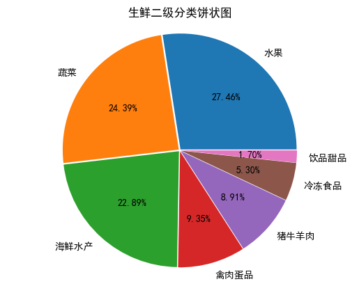

```python
import matplotlib.pyplot as plt
plt.rcParams['font.sans-serif'] = ['SimHei']  # 用来正常显示中文标签
plt.rcParams['axes.unicode_minus'] = False  # 用来正常显示负号

shengxian = catalog[catalog['first'] == '生鲜']['second'].value_counts()
sizes = list(shengxian.values)
plt.pie(sizes, labels = shengxian.keys(),autopct = '%1.2f%%',explode = [0.01] * 7)
plt.title("生鲜二级分类饼状图")  # 设置标题
plt.axis('equal')
plt.show()
```

品类为食品饮料、保健食品的饼状图展示：

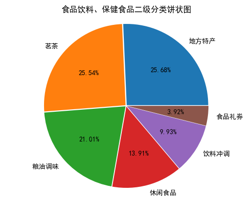

```python
import matplotlib.pyplot as plt
plt.rcParams['font.sans-serif'] = ['SimHei']  # 用来正常显示中文标签
plt.rcParams['axes.unicode_minus'] = False  # 用来正常显示负号

shengxian = catalog[catalog['first'] == '食品饮料、保健食品']['second'].value_counts()
sizes = list(shengxian.values)
plt.pie(sizes, labels = shengxian.keys(),autopct = '%1.2f%%',explode = [0.01] * 6)
plt.title("食品饮料、保健食品二级分类饼状图")  # 设置标题
plt.axis('equal')
plt.show()
```

## 3.分词+词云

导入额外自定义词典、对于生鲜进行分词、提取top100高频词汇制作词云：

```
Building prefix dict from the default dictionary ...
Loading model from cache C:\Users\86153\AppData\Local\Temp\jieba.cache
Loading model cost 0.338 seconds.
Prefix dict has been built successfully.
```

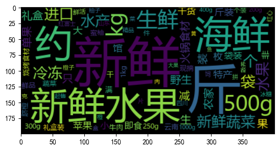

```python
import jieba
from collections import Counter
from wordcloud import WordCloud
names = list(catalog[catalog['first'] == '生鲜']['name'])
names = list(map(str, names))
jieba.load_userdict('data/userdict.dat')
dic = Counter(jieba.lcut(''.join(names))).most_common(100)
top100 = [item[0] for item in dic]
wc = WordCloud(font_path='msyh.ttc').generate(' '.join(top100)) # 需要在目录下有中文字体文件'msyh.ttc'
plt.imshow(wc, interpolation='bilinear')
plt.show()
```

## 4.预处理

去掉纯字母

```python
import re
df = catalog[catalog['first'] == '食品饮料、保健食品']
def tokenize(x):
    x = str(x)
    stop_word_pattern = "\(|\)|[a-zA-Z0-9]"
    x = re.sub(stop_word_pattern, '', x)
    return jieba.lcut(x)
df['tokenize'] = df['name'].apply(lambda x: tokenize(x))
```

对词频进行截断

```python
from tqdm import tqdm
def get_vocabulary(df, low = 10, high = 0.75, top = 1000):
    all_words = []
    high = high * len(df)
    for item in df['tokenize']:
        all_words += item
    s = list(set(all_words))
    dic2 = dict()
    for i in s:
        dic2[i] = 0
    for item in df['tokenize']:
        for word in list(set(item)):
            dic2[word] += 1
    s2 = []
    for i in s:
        if dic2[i] >= low and dic2[i] <= high:
            s2.append(i)
    new_words = []
    for word in tqdm(all_words):
        if word in s2:
            new_words.append(word)
    dic = Counter(new_words)
    cb = dic.most_common(top)
#     voc = [i[0] for i in cb]
    return cb
cb = get_vocabulary(df)
```

```python
# from sklearn.feature_extraction.text import CountVectorizer # 掉包转词向量的快速方法
# voc = [item[0] for item in cb]
# vectorizer = CountVectorizer()
# vectorizer.fit(voc)
# samples = [' '.join(item) for item in df['tokenize']]
# x2 = vectorizer.transform(samples).toarray()
```

[output not shown]

```python
import numpy as np
voc = [item[0] for item in cb]
x = []
for item in tqdm(df['tokenize']):
    x.append([1 if word in item else 0 for word in voc])
```

```python
x = np.asarray(x)
```

## 5.模型训练与评估

```python
from sklearn.model_selection import train_test_split
y = df['second']
dic = list(y.value_counts().keys())
dic2 = dict()
for i, v in enumerate(dic):
    dic2[v] = i
y = y.apply(lambda x: dic2[x])
xtrain, xtest, ytrain, ytest = train_test_split(x,y, test_size = 0.2,random_state = 0)
```

```python
from sklearn.naive_bayes import GaussianNB
gnb=GaussianNB().fit(xtrain,ytrain)
```

```python
ypred = gnb.predict(xtest)
```

```python
from sklearn.metrics import confusion_matrix,accuracy_score
print(confusion_matrix(ytest, ypred))
print(accuracy_score(ytest, ypred))
```

```
[[ 573   85  491  988  223  189]
 [   8 2320   15   22  123   29]
 [  21   43 1643  159  132   97]
 [  12    7   14 1094   64  110]
 [   4    5    5    1  937   13]
 [   4    0    0    8    1  354]]
0.706657137022667
```

从准确率和困惑矩阵看出当前的效果不是很好

## 6.调参

调参思路：先调节top词数量，在结果最优之后，同理更改低截断和高截断参数。

```python
cb2 = get_vocabulary(df, low = 10, high = 0.75, top = 2000)
voc2 = [item[0] for item in cb2]
x2 = []
for item in tqdm(df['tokenize']):
    x2.append([1 if word in item else 0 for word in voc2])
xtrain2, xtest2, ytrain2, ytest2 = train_test_split(x2,y, test_size = 0.2,random_state = 0)
gnb2=GaussianNB().fit(xtrain2,ytrain2)
ypred2 = gnb2.predict(xtest2)
print(accuracy_score(ytest2, ypred2))
```

```
0.7610782111496834
```

```python
cb2 = get_vocabulary(df, low = 10, high = 0.75, top = 3000)
voc2 = [item[0] for item in cb2]
x2 = []
for item in tqdm(df['tokenize']):
    x2.append([1 if word in item else 0 for word in voc2])
xtrain2, xtest2, ytrain2, ytest2 = train_test_split(x2,y, test_size = 0.2,random_state = 0)
gnb2=GaussianNB().fit(xtrain2,ytrain2)
ypred2 = gnb2.predict(xtest2)
print(accuracy_score(ytest2, ypred2))
```

```
0.7851745966918522
```

```python
cb2 = get_vocabulary(df, low = 10, high = 0.75, top = 4000)
voc2 = [item[0] for item in cb2]
x2 = []
for item in tqdm(df['tokenize']):
    x2.append([1 if word in item else 0 for word in voc2])
xtrain2, xtest2, ytrain2, ytest2 = train_test_split(x2,y, test_size = 0.2,random_state = 0)
gnb2=GaussianNB().fit(xtrain2,ytrain2)
ypred2 = gnb2.predict(xtest2)
print(accuracy_score(ytest2, ypred2))
```

```
0.806309985705534
```

```python
cb2 = get_vocabulary(df, low = 10, high = 0.75, top = 5000)
voc2 = [item[0] for item in cb2]
x2 = []
for item in tqdm(df['tokenize']):
    x2.append([1 if word in item else 0 for word in voc2])
xtrain2, xtest2, ytrain2, ytest2 = train_test_split(x2,y, test_size = 0.2,random_state = 0)
gnb2=GaussianNB().fit(xtrain2,ytrain2)
ypred2 = gnb2.predict(xtest2)
print(accuracy_score(ytest2, ypred2))
```

```
0.8206044517051256
```

```python
cb2 = get_vocabulary(df, low = 10, high = 0.75, top = 6000)
voc2 = [item[0] for item in cb2]
x2 = []
for item in tqdm(df['tokenize']):
    x2.append([1 if word in item else 0 for word in voc2])
xtrain2, xtest2, ytrain2, ytest2 = train_test_split(x2,y, test_size = 0.2,random_state = 0)
gnb2=GaussianNB().fit(xtrain2,ytrain2)
ypred2 = gnb2.predict(xtest2)
print(accuracy_score(ytest2, ypred2))
```

```
0.8350010210332857
```

```python
cb2 = get_vocabulary(df, low = 10, high = 0.75, top = 8000)
voc2 = [item[0] for item in cb2]
x2 = []
for item in tqdm(df['tokenize']):
    x2.append([1 if word in item else 0 for word in voc2])
xtrain2, xtest2, ytrain2, ytest2 = train_test_split(x2,y, test_size = 0.2,random_state = 0)
gnb2=GaussianNB().fit(xtrain2,ytrain2)
ypred2 = gnb2.predict(xtest2)
print(accuracy_score(ytest2, ypred2))
```

```
0.8409230140902594
```

```python
cb2 = get_vocabulary(df, low = 10, high = 0.75, top = 10000)
voc2 = [item[0] for item in cb2]
x2 = []
for item in tqdm(df['tokenize']):
    x2.append([1 if word in item else 0 for word in voc2])
xtrain2, xtest2, ytrain2, ytest2 = train_test_split(x2,y, test_size = 0.2,random_state = 0)
gnb2=GaussianNB().fit(xtrain2,ytrain2)
ypred2 = gnb2.predict(xtest2)
print(accuracy_score(ytest2, ypred2))
```

```
0.8409230140902594
```

```python
cb2 = get_vocabulary(df, low = 10, high = 0.75, top = 7000)
voc2 = [item[0] for item in cb2]
x2 = []
for item in tqdm(df['tokenize']):
    x2.append([1 if word in item else 0 for word in voc2])
xtrain2, xtest2, ytrain2, ytest2 = train_test_split(x2,y, test_size = 0.2,random_state = 0)
gnb2=GaussianNB().fit(xtrain2,ytrain2)
ypred2 = gnb2.predict(xtest2)
print(accuracy_score(ytest2, ypred2))
```

```
0.8409230140902594
```

```python
cb2 = get_vocabulary(df, low = 0, high = 0.75, top = 7000)
voc2 = [item[0] for item in cb2]
x2 = []
for item in tqdm(df['tokenize']):
    x2.append([1 if word in item else 0 for word in voc2])
xtrain2, xtest2, ytrain2, ytest2 = train_test_split(x2,y, test_size = 0.2,random_state = 0)
gnb2=GaussianNB().fit(xtrain2,ytrain2)
ypred2 = gnb2.predict(xtest2)
print(accuracy_score(ytest2, ypred2))
```

```
0.8440882172758832
```

```python
cb2 = get_vocabulary(df, low = 0, high = 1, top = 7000)
voc2 = [item[0] for item in cb2]
x2 = []
for item in tqdm(df['tokenize']):
    x2.append([1 if word in item else 0 for word in voc2])
xtrain2, xtest2, ytrain2, ytest2 = train_test_split(x2,y, test_size = 0.2,random_state = 0)
gnb2=GaussianNB().fit(xtrain2,ytrain2)
ypred2 = gnb2.predict(xtest2)
print(accuracy_score(ytest2, ypred2))
```

```
0.8440882172758832
```

```python
cb2 = get_vocabulary(df, low = 0, high = 0.1, top = 7000)
voc2 = [item[0] for item in cb2]
x2 = []
for item in tqdm(df['tokenize']):
    x2.append([1 if word in item else 0 for word in voc2])
xtrain2, xtest2, ytrain2, ytest2 = train_test_split(x2,y, test_size = 0.2,random_state = 0)
gnb2=GaussianNB().fit(xtrain2,ytrain2)
ypred2 = gnb2.predict(xtest2)
print(accuracy_score(ytest2, ypred2))
```

```
0.8435777006330406
```

```python
print(confusion_matrix(ytest2, ypred2))
```

```
[[1451   76  391  564   46   21]
 [  21 2424   21   20   30    1]
 [  49   34 1874  108   24    6]
 [  32    5   20 1214    7   23]
 [   6    6    3    2  948    0]
 [   5    5    2    4    0  351]]
```

调参得到的最优参数是，最佳是用全部词汇（top = 7000 +），不做任何取高值和截断。最佳准确率为84.4%

这可能是因为“食品饮料、保健食品”中的词汇数量较多，并且词频分布相对均匀，高频词和低频词对于分类都具有一定的影响力。